# Problem 1 - Simple Lattice Method

# Problem 2 Wing Planform Distribution Effects

Problem 2 asks us to analyze two different wing planforms and compare different aspects of their aerodynamic efficiency. The first thing we are asked to do is plot the wing plansforms themselves, based on the wing characteristics from Project 6. We can do this pretty easily by creating two functions, one for elliptical wing distributions, and one for trapezoidal wing distributions. For this problem, we'll create the functions and add different aspects as we go.

The 4 plots we need to create are:

- Planform Geometry
- Effective Angle of Attack vs Span
- Sectional Lift / Circulation vs Span
- Washout vs Span

Starting with just the geometry of our trapezoidal wing:

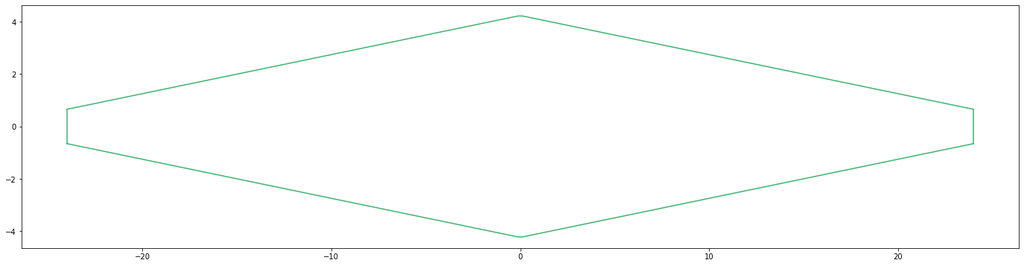

```python
def TrapezoidalWing(b, S, root):
    # b is the span of our wing
    # S is the area of our wing
    # root is the root chord length, we've been given these values in Project 6 and Project 7 Statement

    # First we need a variable for the span of our wing
    span = np.linspace(-b/2, b/2, 200)

    # Then we would like to calculate the chord length of our wing tip
    tip = (2 * S) / b - root

    m = ((root/2) - (tip/2))/ (b/2)
    x = (root/2) - abs(m*span)

    chord = 2 *  x

    return span, chord

span, chord = TrapezoidalWing(48, 235, 8.48)



# From here, we need to plot the various parts of the wing:
plt.figure(figsize = (24 ,6))

# Leading Edge
plt.plot(span, chord/2, color = 'mediumseagreen')

# Trailing Edge
plt.plot(span,-chord/2, color = 'mediumseagreen')

# Left
plt.plot([span[0] , span[0]] ,[-chord[0]/2, chord[0]/2], color = 'mediumseagreen')

# Right
plt.plot([span[-1] , span[-1]] ,[-chord[-1]/2, chord[-1]/2], color = 'mediumseagreen')
plt.show()
```

So far this is pretty simple, lets do the same thing but for the Elliptical Wing planform.

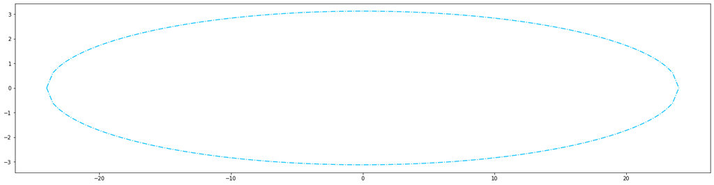

```python
def EllipticalWing(b, S):
    # b is the span of our wing
    # root is the root chord length, we've been given these values in Project 6 and Project 7 Statement
    croot = (4 * S) / (np.pi * b)

    # First we need a variable for the span of our wing
    span = np.linspace(-b/2, b/2, 101)

    # Then we need to calculate the chord of our wing
    chord = 2 *  (croot/2) * np.sqrt(1 - ((span)/(b/2))**2)

    return span, chord

span, chord = EllipticalWing(48, 235)

plt.figure(figsize = (24 ,6))

plt.plot(span, chord/2, color = 'deepskyblue', linestyle = '-.')
plt.plot(span, -chord/2, color = 'deepskyblue', linestyle = '-.')

plt.show()
```

That looks good. Now, lets get these two wings onto the same plot. We can start by modifying both functions to put the plotting functions inside of the function definition. This will look a little bit cleaner:

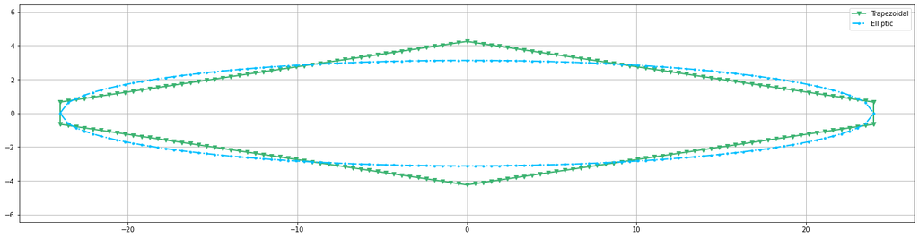

```python
def TrapezoidalWing(b, S, root):
    # b is the span of our wing
    # S is the area of our wing
    # root is the root chord length, we've been given these values in Project 6 and Project 7 Statement

    # First we need a variable for the span of our wing
    span = np.linspace(-b/2, b/2, 101)

    # Then we would like to calculate the chord length of our wing tip
    tip = (2 * S) / b - root

    m = ((root/2) - (tip/2))/ (b/2)
    x = (root/2) - abs(m*span)

    chord = 2 *  x

    # Plotting Functions:
    # Leading Edge
    plt.plot(span, chord/2, color = 'mediumseagreen', linewidth = 2, marker = 'v', label = 'Trapezoidal')

    # Trailing Edge
    plt.plot(span,-chord/2, color = 'mediumseagreen' , linewidth = 2, marker = 'v')

    # Left
    plt.plot([span[0] , span[0]] ,[-chord[0]/2, chord[0]/2], color = 'mediumseagreen' , linewidth = 2, marker = 'v')

    # Right
    plt.plot([span[-1] , span[-1]] ,[-chord[-1]/2, chord[-1]/2], color = 'mediumseagreen' , linewidth = 2, marker = 'v')


    return span, chord

def EllipticalWing(b, S):
    # b is the span of our wing
    # root is the root chord length, we've been given these values in Project 6 and Project 7 Statement
    croot = (4 * S) / (np.pi * b)

    # First we need a variable for the span of our wing
    span = np.linspace(-b/2, b/2, 101)

    # Then we need to calculate the chord of our wing
    chord = 2 *  (croot/2) * np.sqrt(1 - ((span)/(b/2))**2)

    # Plotting Functions
    plt.plot(span, chord/2, color = 'deepskyblue', linestyle = '-.', linewidth = 2, marker = '.', label = 'Elliptic')
    plt.plot(span, -chord/2, color = 'deepskyblue', linestyle = '-.', linewidth = 2, marker = '.')


    return span, chord

# Now, we just need to create a new figure and then run both functions.

plt.figure(1, figsize = (24 ,6))
span, cT = TrapezoidalWing(48, 235, 8.48)
span, cE = EllipticalWing(48, 235)
plt.legend(loc = 'best')
plt.grid(True)
plt.axis('equal')
plt.show()
```

# Problem 2 , Circulation, Effective Angle of Attack and Washout

Our next step is to calculate the Effective angle of attack $\alpha_{eff}$, our circulation, and washout w of each point on our planforms. Each of these values is closely related for a finite wing. The process to calculate circulation is typically very involved, and requires an iterative process. Rather than have you implement this code yourself, we have provided the circulation data per unit span on Canvas. Lets start by unpacking and loading this data. All you have to do for this problem is load the data from the two circulation files and plot the circulation over the span of the wings.

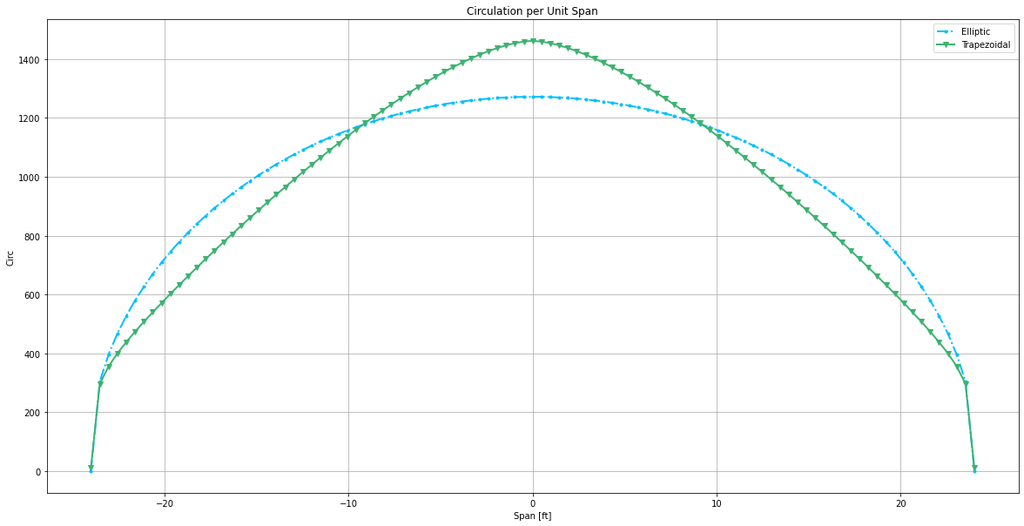

This is the first of a few plots that we need, but we can take a moment to examine the results from the above plot. 0 span is essentially the wing root. What our plot is telling us is that the circulation about our wing is a maximum at the root of the wing (where the chord is longest and there are no wingtips) and decreases as we move out to the wing tips. The trapezoidal wing has a higher circulation at the root whereas the elliptical wing starts to produce more circulation at about the half way point of the span.

A few things you should consider at this point are: we performed this analysis for a given area S, both the trapezoidal wing planform and the elliptical wing planform produce similar amounts of circulation. One change between the planforms, we did have to reduce the root chord of the elliptic wing in order to maintain the same area S for both wings. From our circulation data above, we can also calculate the value of sectional lift, or the lift per unit span at different points on the wing.